# Lab Week 03 - Linear Regression - Part 1

Pouria

1/24/2022

# Lab 1

In this first exercise, we will simulate different datasets with

$$y = 2 + 3 *X + \epsilon,$$

with $X$ randomly generated via a uniform distribution from 0 to 10, and $\epsilon$ generated via a normal (Gaussian) distribution of 0 mean and variance 1 (which we note, $\epsilon \sim N(\mu, \sigma^2)$, where $\mu=0$ and $\sigma=1$)

1. Generate 10 “experiments” with 5 observations each. Compute the slopes and the intercepts using the formula of equation 3.4, check that the values are the same as given by the `lm()` function in R , and plot the 10 different lines. Also plot in bold the “true” line.
2. Now repeat 10 experiments, but with 20 observations each. Plot the 10 different lines. What do you conclude?
3. For each 5 and 20 observations, use the formula of equations 3.8 to compute the SE for the slope.
- Plot the SEs in both conditions.
- Is this this difference statistically significant?
- Why is the SE smaller for 20 observations?

Equation 3.8:

$$SE(\hat{\beta_0})^2 = \sigma^2[\frac{1}{n} + \frac{\bar{x}^2}{\sum_{i=1}^{n}(x_i-\bar{x})^2 }],$$
$$SE(\hat{\beta_1})^2 = \frac{\sigma^2}{\sum_{i=1}^{n}(x_i-\bar{x})^2 }$$

# Solution 1(a)

### Coefficients for 5 observations from 10 experiments

```
##       beta0    beta1 beta0_lm beta1_lm  SE_beta1
## 1  3.846215 2.749609 3.846215 2.749609 0.1464893
## 2  1.838607 2.968596 1.838607 2.968596 0.1932024
## 3  3.088106 2.919039 3.088106 2.919039 0.1513485
## 4  1.365515 3.142826 1.365515 3.142826 0.2033624
## 5  1.700941 2.950730 1.700941 2.950730 0.1279172
## 6  2.830966 2.773279 2.830966 2.773279 0.1495055
## 7  1.171279 3.148307 1.171279 3.148307 0.2145426
## 8  1.119755 3.107888 1.119755 3.107888 0.1350628
## 9  3.235203 2.581331 3.235203 2.581331 0.2738390
## 10 2.174937 2.997381 2.174937 2.997381 0.1376091
```

# Solution 1(a)

### Visualize for 5 observations from 10 experiments

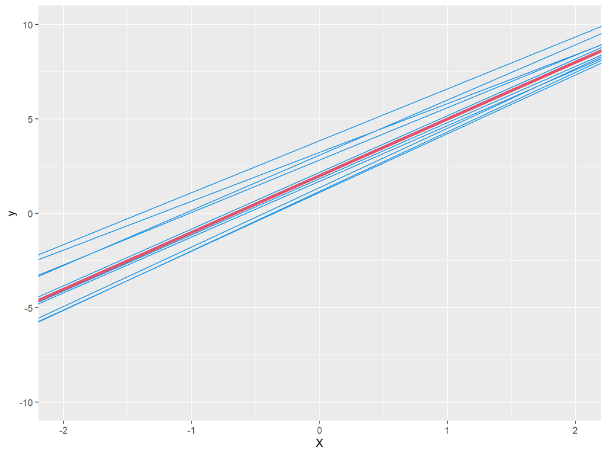

# Solution 1(b)

### Coefficients for 20 observations from 10 experiments;

Compare with `lm()`

```
##       beta0    beta1 beta0_lm beta1_lm   SE_beta1
## 1  1.514628 3.089827 1.514628 3.089827 0.09324232
## 2  2.030858 3.012076 2.030858 3.012076 0.07719243
## 3  1.962279 2.991504 1.962279 2.991504 0.07598554
## 4  1.856277 3.021951 1.856277 3.021951 0.07175494
## 5  2.065932 3.029941 2.065932 3.029941 0.07579342
## 6  1.732474 2.993095 1.732474 2.993095 0.08577930
## 7  2.048113 2.974460 2.048113 2.974460 0.08775834
## 8  1.319062 3.088747 1.319062 3.088747 0.09078009
## 9  1.257187 3.105126 1.257187 3.105126 0.07305575
## 10 1.836190 2.982284 1.836190 2.982284 0.09613531
```

# Solution 1(b)

### Visualize for 20 observations from 10 experiments

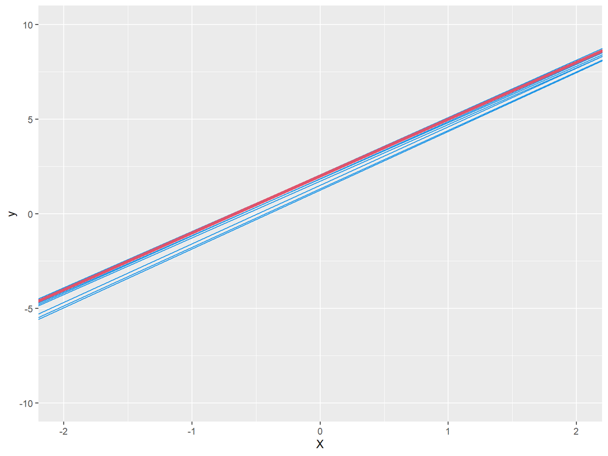

# Lab 1(c)

For each 5 and 20 observations, use the formula of equations 3.8 to compute the SE for the slope.

- Plot the SEs in both conditions.
- Is this this difference statistically significant?
- Why is the SE smaller for 20 observations?

Equation 3.8:

$$SE(\hat{\beta_0})^2 = \sigma^2[\frac{1}{n} + \frac{\bar{x}^2}{\sum_{i=1}^{n}(x_i-\bar{x})^2 }],$$
$$SE(\hat{\beta_1})^2 = \frac{\sigma^2}{\sum_{i=1}^{n}(x_i-\bar{x})^2 }$$

# Solution 1(c)

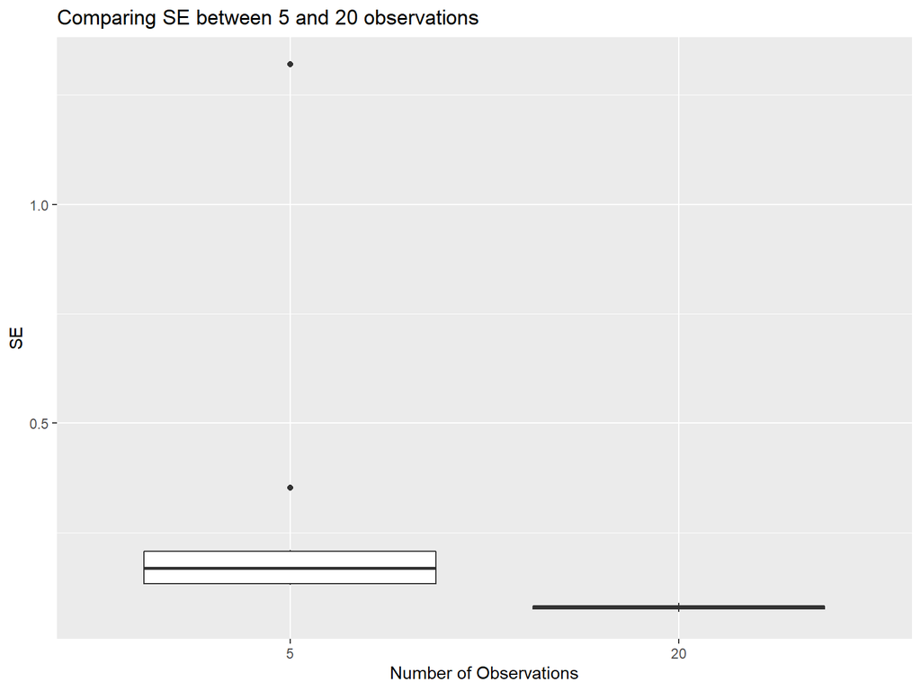

# Lab 2

Now we will try to estimate coefficients of a linear regression model via systematic simulations

1. We now use the following model

$$y = 7 + 0.05 *X + \sigma,$$

with $\sigma \sim N(0, 1))$

2. Plot the regression line with 100 observations
3. Now using 2 for loops over the parameters with about 100 steps for each parameter, generate a figure like figure 3.2A in the book (use similar parameter ranges).
4. Find the minimum of RSS curve using `min()`? Plot the minimum on the figure. How does this compare with the parameters given by the `lm()`?
5. Now repeat with about 5 steps for each parameter. Generate the figure again. How does this compare with the parameters given by the `lm()`? What do you conclude?
6. *Bonus*: generate 3D plots like figure 3.2B

# Solution 2(b)

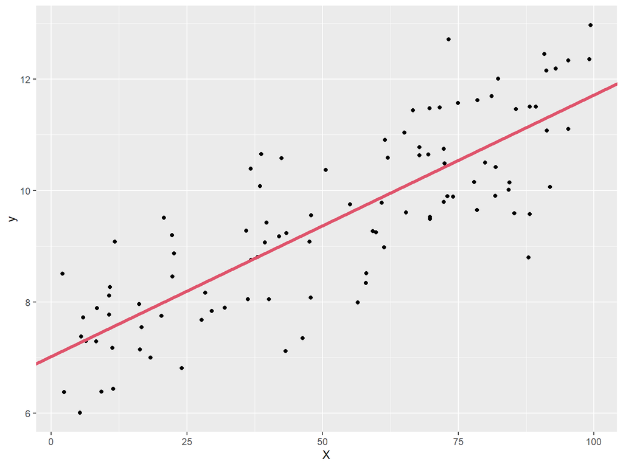

# Solution 2(c)

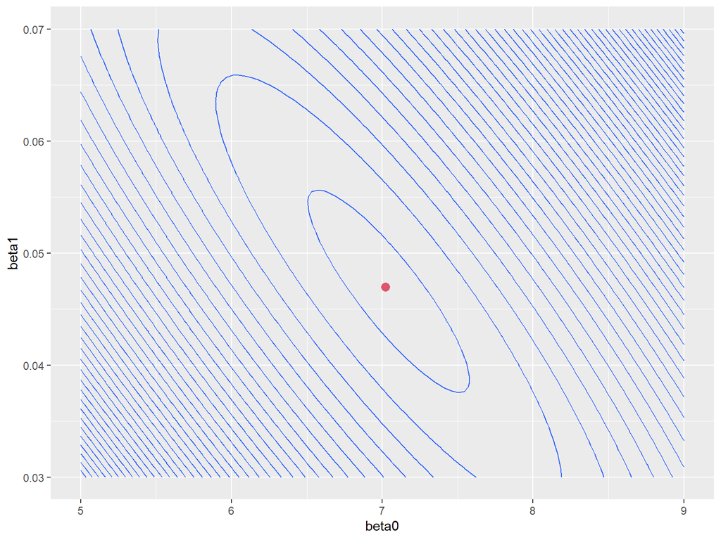

# Solution 2(d)

```
##             beta0.opt beta1.opt beta0.lm   beta1.lm
## (Intercept)  7.020202 0.0469697 7.041384 0.04660032
```

# Solution 2(e): Regression

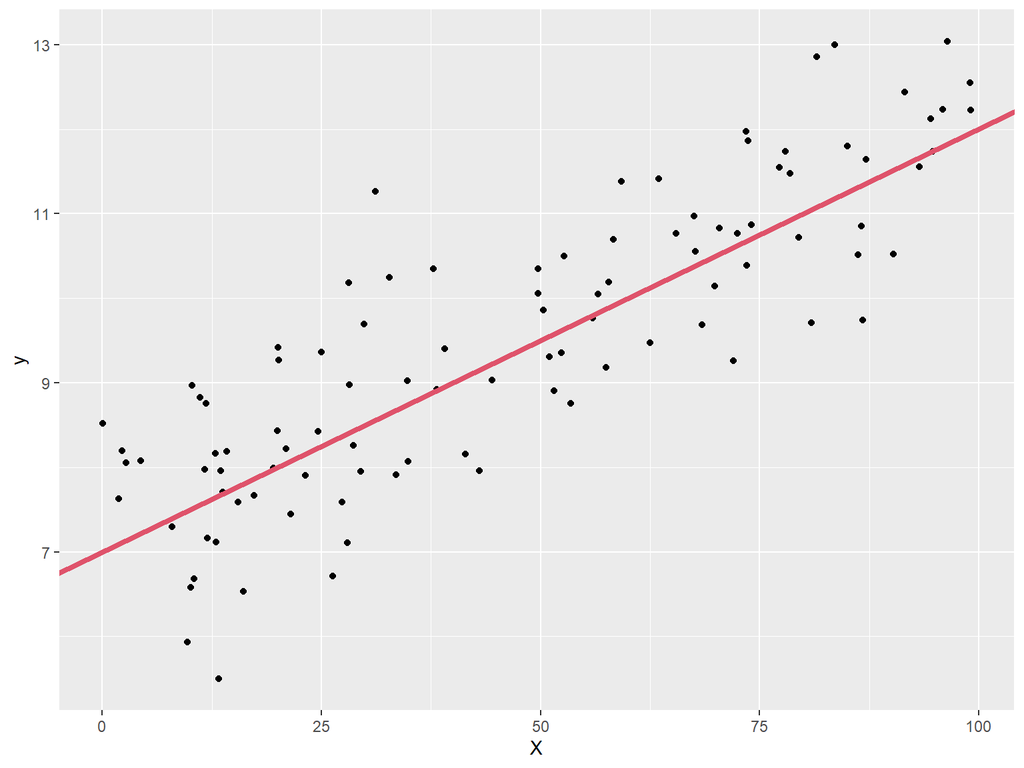

# Solution 2(e): Contour plot

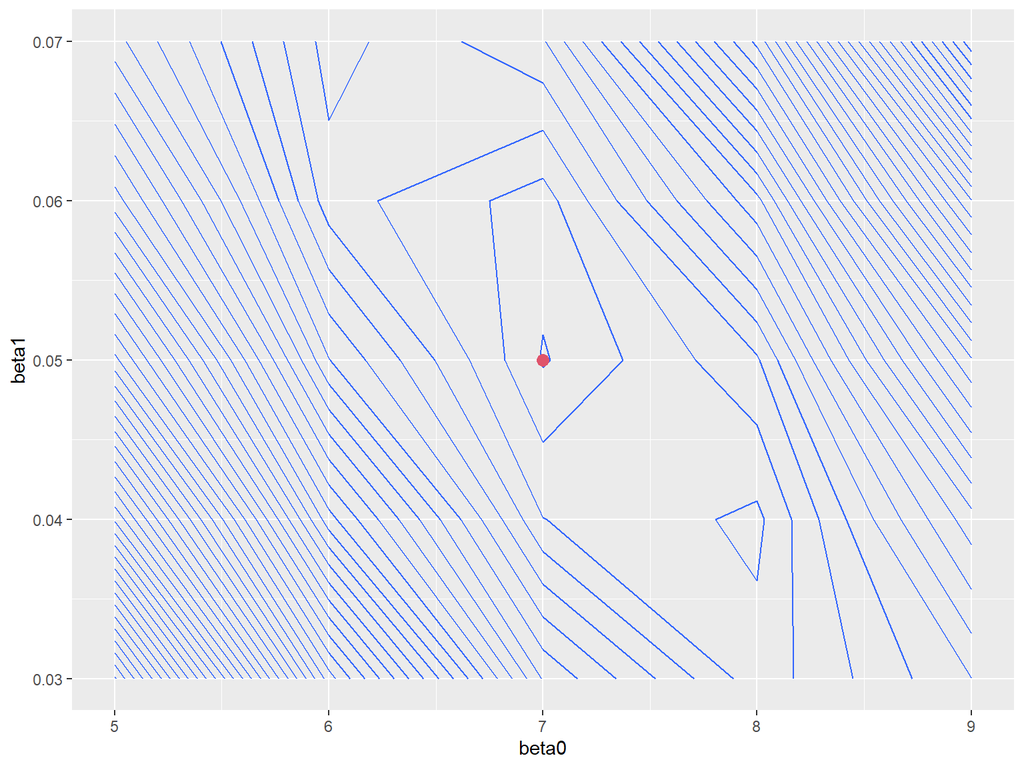

# Solution 2(e): Compare Coefficients

```
##             beta0.opt beta1.opt beta0.lm   beta1.lm
## (Intercept)         7      0.05 7.168524 0.05014927
```

# Lab 3

Now we will try to estimate the parameters via a method called “gradient descent”. Given a random starting point, we will “descend” along the steepest gradient in parameter space until we converge to the minimum.

$$\hat{y}=X\theta$$
$$L=\frac{1}{2m}\sum_{i=1}^{m}(y_i-\hat{y}_i)^2$$
$$L=\frac{1}{2m}(\mathbf{y}-X\theta)^T(\mathbf{y}-X\theta)$$